# Unit 2 Walkthrough: Twitter Sentiment and School Reform

Dr. Shaun Kellogg

2021-04-24

## 0. INTRODUCTION

This week, our walkthrough is guided by my colleague Josh Rosenberg’s recent article, **Advancing new methods for understanding public sentiment about educational reforms: The case of Twitter and the Next Generation Science Standards.** We will focus on conducting a very simplistic “replication study” by comparing the sentiment of tweets about the [Next Generation Science Standards](https://www.nextgenscience.org) (NGSS) and [Common Core State Standards](http://www.corestandards.org) (CCSS) in order to better understand public reaction to these two curriculum reform efforts. I highly recommend you watch the quick 3-minute overview of this work at https://stanford.app.box.com/s/i5ixkj2b8dyy8q5j9o5ww4nafznb497x

### Walkthrough Focus

For Unit 2, our focus will be on using the Twitter API to import data on topics or tweets of interest and using sentiment lexicons to help gauge public opinion about those topics or tweets. Silge & Robinson nicely illustrate the tools of text mining to approach the emotional content of text programmatically, in the following diagram:

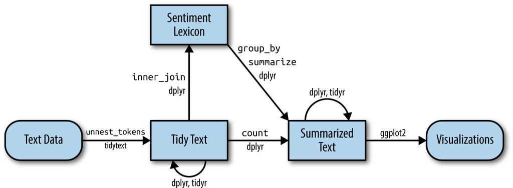

For Unit 2, our walkthrough will cover the following topics:

1. **Prepare**: Prior to analysis, it’s critical to understand the context and data sources you’re working with so you can formulate useful and answerable questions. We’ll take a quick look at Dr. Rosenberg’s study as well as data available through Twitter’s API.
2. **Wrangle**: In section 2 we revisit tidying and tokenizing text from Unit 1, and and learn some new functions for appending sentiment scores to our tweets using the AFFIN, bing, and nrc sentiment lexicons.
3. **Explore**: In section 3, we use simple summary statistics and basic data visualization to compare sentiment between NGSS and CCSS tweets.
4. **Model**: While we won’t leverage modeling approaches until Unit 3, we will examine the mixed effects model used by Rosenberg et al. to analyze the sentiment of tweets
5. **Communicate:** Finally, in Week 7 we’ll create a basic presentation, report, or other data product for sharing findings and insights from our analysis.

## 1. PREPARE

To help us better understand the context, questions, and data sources we’ll be using in Unit 2, this section will focus on the following topics:

1. **Context**. We take a quick look at the Rosenberg et al. (2021) article, *Advancing new methods for understanding public sentiment about educational reforms*, including the purpose of the study, questions explored, and findings.
2. **Questions.** We’ll formulate some basic questions that we’ll use to guide our analysis, attempting to replicate some of the findings by Rosenberg et al.
3. **Twitter Setup** We walkthrough the process of setting up R to pull data from our Twitter developer account created during the first week of the course.

### 1a. Some Context

#### **Twitter and the Next Generation Science Standards**

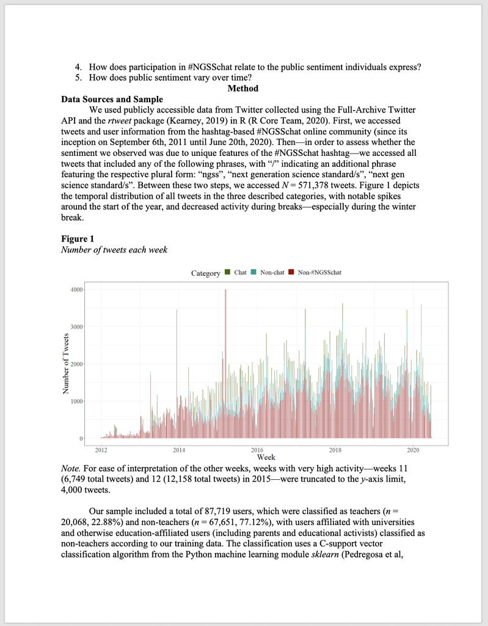

[Full Paper (Preprint)](https://osf.io/xymsd/.)

**Abstract**

While the Next Generation Science Standards (NGSS) are a long-standing and widespread standards-based educational reform effort, they have received less public attention, and no studies have explored the sentiment of the views of multiple stakeholders toward them. To establish how public sentiment about this reform might be similar to or different from past efforts, we applied a suite of data science techniques to posts about the standards on Twitter from 2010-2020 (N = 571,378) from 87,719 users. Applying data science techniques to identify teachers and to estimate tweet sentiment, we found that the public sentiment towards the NGSS is overwhelmingly positive—33 times more so than for the CCSS. Mixed effects models indicated that sentiment became more positive over time and that teachers, in particular, showed a more positive sentiment towards the NGSS. We discuss implications for educational reform efforts and the use of data science methods for understanding their implementation.

**Data Source & Analysis**

Similar to what we’ll be learning in this walkthrough, Rosenberg et al. used publicly accessible data from Twitter collected using the Full-Archive Twitter API and the `rtweet` package in R. Specifically, the authors accessed tweets and user information from the hashtag-based #NGSSchat online community, all tweets that included any of the following phrases, with “/” indicating an additional phrase featuring the respective plural form: “ngss”, “next generation science standard/s”, “next gen science standard/s”.

Note that the authors also used the `lme4` package in R to run a mixed effects model to determine if sentiment changes over time and differs between teachers and non-teacher. We will not attempt replicated that aspect of the analysis, but if you are interested in a guided walkthrough of how modeling can be used to understand changes in Twitter word use, see [Chapter 7 of Text Mining with R](https://www.tidytextmining.com/twitter.html#changes-in-word-use).

**Summary of Key Findings**

1. Contrasting with sentiment about CSSS, sentiment about the NGSS science education reform effort is overwhelmingly positive, with approximately 9 positive tweets for every negative tweet.
2. Teachers were more positive than non-teachers, and sentiment became substantially more positive over the ten years of NGSS-related posts.
3. Differences between the context of the tweets were small, but those that did not include the #NGSSchat hashtag became more positive over time than those posts that did not include the hashtag.
4. Individuals posted more tweets during #NGSSchat chats, the sentiment of their posts was more positive, suggesting that while the context of individual tweets has a small effect (with posts not including the hashtag becoming more positive over time), the effect upon individuals of being involved in the #NGSSchat was positive.

### 1b. Guiding Questions

The Rosenberg et al. study was guided by the following five research questions:

1. What is the public sentiment expressed toward the NGSS?
2. How does sentiment for teachers differ from non-teachers?
3. How do tweets posted to #NGSSchat differ from those without the hashtag?
4. How does participation in #NGSSchat relate to the public sentiment individuals express?
5. How does public sentiment vary over time?

For this walkthrough, we’ll use a similar approach used by the authors to guage public sentiment around the NGSS, by compare how much more positive or negative NGSS tweets are relative to CSSS tweets.

Our (very) specific questions of interest for this walkthrough are:

1. What is the public sentiment expressed toward the NGSS?
2. How does sentiment for NGSS compare to sentiment for CCSS?

And just to reiterate from Unit 1, one overarching question we’ll explore throughout this course, and that Silge and Robinson (2018) identify as a central question to text mining and natural language processing, is:

> How do we to **quantify** what a document or collection of documents is about?

### 1c. Set Up

As highlighted in [Chapter 6 of Data Science in Education Using R](https://datascienceineducation.com/c06.html) (DSIEUR), one of the first steps of every workflow should be to set up a “Project” within RStudio. This will be your “home” for any files and code used or created in Unit 2. You are welcome to continue using the same project created for Unit 1, or create an entirely new project for Unit 2. However, after you’ve created your project open up a new R script, and load the following packages that we’ll be needing for this walkthrough:

```r
library(dplyr)
library(readr)
library(tidyr)
library(rtweet)
library(writexl)
library(readxl)
library(tidytext)
library(textdata)
library(ggplot2)
library(textdata)
library(scales)
```

At the end of this week, I’ll ask that you share with me your r script as evidence that you have complete the walkthrough. Although I highly recommend that that you manually type the code shared throughout this walkthrough, for large blocks of text it may be easier to copy and paste.

#### Create a Twitter App

Before you can begin pulling tweets into R, you’ll first need to create a Twitter App in your developer account. You are not required to set up developer account for this course, but if you are still interested in creating one, [these instructions](https://dev.to/sumedhpatkar/beginners-guide-how-to-apply-for-a-twitter-developer-account-1kh7) succinctly outline the process and you can set one up in about 10 minutes. If you are not interested in setting one up and pulling tweets on your own, I have provided the data we’ll be using for this tutorial on my [GitHub course repository](https://github.com/sbkellogg/eci-588/tree/main/unit-2/data) and in our ECI 588 course site. You can skip to section 2b. Tidy Text.

This section and the section that follows, are borrowed largely from `rtweet` package by Michael Kearney, and is for those of you have a set up a Twitter developer account and are interested in pulling your own data for Twitter.

1. Navigate to [developer.twitter.com/en/apps](https://developer.twitter.com/en/apps/), click the blue button that says, `Create a New App`, and then complete the form with the following fields:
   - `App Name`: What your app will be called
   - `Application Description`: How your app will be described to its users

[figure not shown]

   - `Website URLs`: Website associated with app–I recommend using the URL to your Twitter profile
   - `Callback URLs`: *IMPORTANT* enter exactly the following: `http://127.0.0.1:1410`

[figure not shown]

   - `Tell us how this app will be used`: Be clear and honest

[figure not shown]

2. When you’ve completed the required form fields, click the blue `Create` button at the bottom
3. Read through and indicate whether you accept the developer terms

[figure not shown]

4. And you’re done!

[figure not shown]

#### Authorization methods

Users can create their personal Twitter token in two different ways. Each method is outlined below.

- Navigate to developer.twitter.com/en/apps and select your Twitter app
- Click the tab labeled `Keys and tokens` to retrieve your keys.
- Locate the `Consumer API keys` (aka “API Secret”).

[figure not shown]

- Scroll down to `Access token & access token secret` and click `Create`

[figure not shown]

- Copy and paste the four keys (along with the name of your app) into an R script file and pass them along to `create_token()`. Note, these keys are named secret for a reason. I recommend setting up your token in a separate R script than the one that you will eventually share.

```r
## store api keys (these are fake example values; replace with your own keys)
app_name <- "Text Mining in Education"
api_key <- "afYS4vbIlPAj096E60c4W1fiK"
api_secret_key <- "bI91kqnqFoNCrZFbsjAWHD4gJ91LQAhdCJXCj3yscfuULtNkuu"
access_token <- "9551451262-wK2EmA942kxZYIwa5LMKZoQA4Xc2uyIiEwu2YXL"
access_token_secret <- "9vpiSGKg1fIPQtxc5d5ESiFlZQpfbknEN1f1m2xe5byw7"

## authenticate via web browser
token <- create_token(
  app = app_name,
  consumer_key = api_key,
  consumer_secret = api_secret_key,
  access_token = access_token,
  access_secret = access_token_secret)
```

#### Authorization in future R sessions

- The `create_token()` function should automatically save your token as an environment variable for you. So next time you start an R session [on the same machine], rtweet should automatically find your token.
- To make sure it works, restart your R session, run the following code, and again check to make sure the app name and `api_key` match.

```r
## check to see if the token is loaded
get_token()
```

```
## <Token>
## <oauth_endpoint>
##  request:   https://api.twitter.com/oauth/request_token
##  authorize: https://api.twitter.com/oauth/authenticate
##  access:    https://api.twitter.com/oauth/access_token
## <oauth_app> Text Mining in Education
##   key:    6R7OuvUoXm5XLuZS6Wk0WrtIn
##   secret: <hidden>
## <credentials> oauth_token, oauth_token_secret
## ---
```

That’s it!

## 2. WRANGLE

In general, data wrangling involves some combination of cleaning, reshaping, transforming, and merging data (Wickham & Grolemund, 2017). The importance of data wrangling is difficult to overstate, as it involves the initial steps of going from raw data to a dataset that can be explored and modeled (Krumm et al, 2018).

1. **Import Data**. In this section, we introduce the `rtweet` package and some key functions to search for tweets or users of interest.
2. **Tidy Tweets**. We revisit the `tidytext` package to both “tidy” and tokenize our tweets in order to create our data frame for analysis.
3. **Get Sentiments**. We conclude our data wrangling by introducing sentiment lexicons and the `inner_join()` function for appending sentiment values to our data frame.

### 2a. Import Tweets

The Import Tweets section introduces the following functions from the `rtweet` package for reading Twitter data into R:

- [`search_tweets()`](https://www.rdocumentation.org/packages/rtweet/versions/0.7.0/topics/search_tweets) Pulls up to 18,000 tweets from the last 6-9 days matching provided search terms.
- [`search_tweets2()`](https://www.rdocumentation.org/packages/rtweet/versions/0.7.0/topics/search_tweets) Returns data from **multiple** search queries.
- [`get_timelines()`](https://www.rdocumentation.org/packages/rtweet/versions/0.7.0/topics/search_tweets) Returns up to 3,200 tweets of one or more specified Twitter users.

#### Search Tweets

Since one of our goals for this walkthrough is a very crude replication of the study by Rosenberg et al. (2021), let’s begin by introducing the `search_tweets()` function to try reading into R 5,000 tweets containing the NGSS hashtag and store as a new data frame `ngss_all_tweets`.

Type or copy the following code into your R script or console and run:

```r
ngss_all_tweets <- search_tweets(q = "#NGSSchat", n=5000)
```

Note that the first argument `q =` that the `search_tweets()` function expects is the search term included in quotation marks and that `n =` specifies the maximum number of tweets

##### ✅ Comprehension Check

View your new `ngss_all_tweets`data frame using one of the previous view methods from Unit 1 Section 2a to help answer the following questions:

1. How many tweets did our query using the Twitter API actually return? How many variables?
2. Why do you think our query pulled in far less than 5,000 tweets requested?
3. Does our query also include retweets? How do you know?

#### Remove Retweets

While not explicitly mentioned in the paper, it’s likely the authors removed retweets in their query since a retweet is simply someone else reposting someone else’s tweet and would duplicate the exact same content of the original.

Let’s use the `include_rts =` argument to remove any retweets by setting it to `FALSE`:

```r
ngss_non_retweets <- search_tweets("#NGSSchat",
                                   n=5000,
                                   include_rts = FALSE)
```

#### Using the OR Operator

If you recall from [Section 1a], the authors accessed tweets and user information from the hashtag-based #NGSSchat online community, all tweets that included any of the following phrases, with “/” indicating an additional phrase featuring the respective plural form: “ngss”, “next generation science standard/s”, “next gen science standard/s”.

Let’s modify our query using the `OR` operator to also include “ngss” so it will return tweets containing either #NGSSchat or “ngss” and assign to `ngss_or_tweets`:

```r
ngss_or_tweets <- search_tweets(q = "#NGSSchat OR ngss",
                                n=5000,
                                include_rts = FALSE)
```

##### ✅ Comprehension Check

Try including both search terms but excluding the `OR` operator to answer the following question:

1. Does excluding the `OR` operator return more tweets, the same number of tweets, or fewer tweets? Why?
2. What other useful arguments does the `search_tweet()` function contain? Try adding one and see what happens.

Hint: Use the `?search_tweets` help function to learn more about the `q` argument and other arguments for composing search queries.

#### Use Multiple Queries

Unfortunately, the `OR` operator will only get us so far. In order to include the additional search terms, we will need to use the `c()` function to combine our search terms into a single list.

The `rtweets` package has an additional `search_tweets2()` function for using multiple queries in a search. To do this, either wrap single quotes around a search query using double quotes, e.g., `q = '"next gen science standard"'` or escape each internal double quote with a single backslash, e.g., `q = "\"next gen science standard\""`.

Copy and past the following code to store the results of our query in `ngss_tweets`:

```r
ngss_tweets <- search_tweets2(c("#NGSSchat OR ngss",
                                '"next generation science standard"',
                                '"next generation science standards"',
                                '"next gen science standard"',
                                '"next gen science standards"'
                                   ),
                             n=5000,
                             include_rts = FALSE)
```

#### Our First Dictionary

Recall that for our research question we wanted to compare public sentiment about both the NGSS and CCSS state standards. Let’s go ahead and create our very first “dictionary” for identifying tweets related to either set of standards, and then use that dictionary for our the `q =` query argument to pull tweets related to the state standards.

To do so, we’ll need to add some additional search terms to our list:

```r
ngss_dictionary <- c("#NGSSchat OR ngss",
                     '"next generation science standard"',
                     '"next generation science standards"',
                     '"next gen science standard"',
                     '"next gen science standards"')

ngss_tweets <- search_tweets2(ngss_dictionary,
                              n=5000,
                              include_rts = FALSE)
```

Now let’s create a dictionary for the Common Core State Standards and pass that to our `search_tweets()` function to get the most recent tweets:

```r
ccss_dictionary <- c("#commoncore", '"common core"')

ccss_tweets <- ccss_dictionary %>%
  search_tweets2(n=5000, include_rts = FALSE)
```

Notice that you can use the pipe operator with the `search_tweets()` function just like you would other functions from the tidyverse.

##### ✅ Comprehension Check

1. Use the `search_tweets` function to create you own custom query for a twitter hashtag or topic(s) of interest.

#### Write to Excel

Finally, let’s save our tweet files to use in later exercises since tweets have a tendency to change every minute. We’ll save as a Microsoft Excel file since one of our columns can not be stored in a flat file like .csv.

Let’s use the `write_xlsx()` function from the `writexl` package just like we would the `write_csv()` function from `dplyr` in Unit 1:

```r
write_xlsx(ngss_tweets, "data/ngss_tweets.xlsx")
write_xlsx(ccss_tweets, "data/csss_tweets.xlsx")
```

#### Other Useful Queries

For your independent analysis, you may be interest in exploring posts by specific users rather than topics, key words, or hashtags. Yes, there is a function for that too!

For example, let’s create another list containing the usernames of me and some of my colleagues at the Friday Institute using the `c()` function again and use the `get_timelines()` function to get the most recent tweets from each of those users:

```r
fi <- c("sbkellogg", "mjsamberg", "haspires", "tarheel93", "drcallie_tweets", "AlexDreier")

fi_tweets <- fi %>%
  get_timelines(include_rts=FALSE)
```

And let’s use the `sample_n()` function from the `dplyr` package to pick 10 random tweets and use `select()` to select and view just the `screenname` and `text` columns that contains the user and the content of their post:

```r
sample_n(fi_tweets, 10) %>%
  select(screen_name, text)
```

```
## # A tibble: 10 x 2
##    screen_name     text
##    <chr>           <chr>
##  1 haspires        "My heart breaks for the victims of last night's violence in…
##  2 drcallie_tweets "@AlexDreier I wholeheartedly agree 💯Context matters. I saw …
##  3 tarheel93       "Parents are scheduled for COVID vaccine early tomorrow morn…
##  4 haspires        "Wisdom in action. @FridayInstitute https://t.co/pbQc8lTWdk"
##  5 drcallie_tweets "@DrCKMarshall @FridayInstitute @robmoore3 Yay!! Congratulat…
##  6 drcallie_tweets "Excited to present today at #AERA21 with @boulded! Our pape…
##  7 mjsamberg       "I've always wanted to learn to speak Yiddish - my mom's par…
##  8 AlexDreier      "“...at the Navy base where he worked.” \n\nI have questions…
##  9 drcallie_tweets "Attending this session right now! ⬇️🤓 https://t.co/0XN0mjEJ5…
## 10 sbkellogg       "@robmoore3 @yanecnu It’s that slim window of time between w…
```

We’ve only scratched the surface of the number of functions available in the `rtweets` package for searching Twitter. Use the following function to

```r
vignette("intro", package="rtweet")
```

##### ✅ Comprehension Check

To conclude Section 2a, try one of the following search functions from the `rtweet` vignette:

1. `get_timelines()` Get the most recent 3,200 tweets from users.
2. `stream_tweets()` Randomly sample (approximately 1%) from the live stream of all tweets.
3. `get_friends()` Retrieve a list of all the accounts a user follows.
4. `get_followers()` Retrieve a list of the accounts following a user.
5. `get_favorites()` Get the most recently favorited statuses by a user.
6. `get_trends()` Discover what’s currently trending in a city.
7. `search_users()` Search for 1,000 users with the specific hashtag in their profile bios.

### 2b. Tidy Text

Now that we have the data needed to answer our questions, we still have a little bit of work to do to get it ready for analysis. This section will revisit some familiar functions from Unit 1 and introduce a couple new functions:

#### Functions Used

**`dplyr` functions**

- `select()` picks variables based on their names.
- `slice()` lets you select, remove, and duplicate rows.
- `rename()` changes the names of individual variables using new_name = old_name syntax
- `filter()` picks cases, or rows, based on their values in a specified column.

**`tidytext` functions**

- `unnest_tokens()` splits a column into tokens
- `anti_join()` returns all rows from x with**out** a match in y.

**ATTENTION:** For those of you who do not have Twitter Developer accounts, you will need to read in the Excel files share in our Course site and also located here: https://github.com/sbkellogg/eci-588/tree/main/unit-2/data

We’ll use the `readxl` package highlighted in Unit 1 and the `read_xlsx()` function to read in the data stored in the data folder of our R project:

```r
ngss_tweets <- read_xlsx("data/ngss_tweets.xlsx")
ccss_tweets <- read_xlsx("data/csss_tweets.xlsx")
```

**Note:** If you have already created these data frames from 2a. Import Tweets, you do not need to read these file into R unless you want to reproduce the exact same outputs shown in the rest of this walkthrough.

#### Subset Rows & Columns

As you are probably already aware, we have way more data than we’ll need for analysis and will need to pare it down quite a bit.

First, let’s use the `filter` function to subset rows containing only tweets in the language:

```r
ngss_text <- filter(ngss_tweets, lang == "en")
```

Now let’s select the following columns from our new `ngss_text` data frame:

1. `screen_name` of the user who created the tweet
2. `created_at` timestamp for examining changes in sentiment over time
3. `text` containing the tweet which is our primary data source of interestt

```r
ngss_text <- select(ngss_text,screen_name, created_at, text)
```

#### Add & Reorder Columns

Since we are interested in comparing the sentiment of NGSS tweets with CSSS tweets, it would be helpful if we had a column for quickly identifying the set of state standards, with which each tweet is associated.

We’ll use the `mutate()` function to create a new variable called `standards` to label each tweets as “ngss”:

```r
ngss_text <- mutate(ngss_text, standards = "ngss")
```

And just because it bothers me, I’m going to use the `relocate()` function to move the `standards` column to the first position so I can quickly see which standards the tweet is from:

```r
ngss_text <- relocate(ngss_text, standards)
```

Note that you could also have used the `select()` function to reorder columns like so:

```r
ngss_text <- select(ngss_text, standards, screen_name, created_at, text)
```

Finally, let’s rewrite the code above using the `%>%` operator so there is less redundancy and it is easier to read:

```r
ngss_text <-
  ngss_tweets %>%
  filter(lang == "en") %>%
  select(screen_name, created_at, text) %>%
  mutate(standards = "ngss") %>%
  relocate(standards)
```

##### ✅ Comprehension Check

**WARNING:** You will not be able to progress to the next section until you have completed the following task:

1. Create an new `ccss_text` data frame for our `ccss_tweets` Common Core tweets by modifying code above.

#### Combine Data Frames

Finally, let’s combine our `ccss_text` and `ngss_text` into a single data frame by using the `bind_rows()` function from `dplyr` to simply supplying the data frames that you want to combine as arguments:

```r
tweets <- bind_rows(ngss_text, ccss_text)
```

And let’s take a quick look at both the `head()` and the `tail()` of this new `tweets` data frame to make sure it contains both “ngss” and “ccss” standards:

```r
head(tweets)
```

```
## # A tibble: 6 x 4
##   standards screen_name  created_at          text
##   <chr>     <chr>        <dttm>              <chr>
## 1 ngss      loyr2662     2021-02-27 17:33:27 "Switching gears for a bit for the…
## 2 ngss      loyr2662     2021-02-20 20:02:37 "Was just introduced to the Engine…
## 3 ngss      Furlow_teach 2021-02-27 17:03:23 "@IBchemmilam @chemmastercorey I’m…
## 4 ngss      Furlow_teach 2021-02-27 14:41:01 "@IBchemmilam @chemmastercorey How…
## 5 ngss      TdiShelton   2021-02-27 14:17:34 "I am so honored and appreciative …
## 6 ngss      TdiShelton   2021-02-27 15:49:17 "Thank you @brian_womack I loved c…
```

```r
tail(tweets)
```

```
## # A tibble: 6 x 4
##   standards screen_name  created_at          text
##   <chr>     <chr>        <dttm>              <chr>
## 1 ccss      JosiePaul88… 2021-02-20 00:34:53 "@SenatorHick You realize science …
## 2 ccss      ctwittnc     2021-02-19 23:44:18 "@winningatmylife I’ll bet none of…
## 3 ccss      the_rbeagle  2021-02-19 23:27:06 "@dmarush @electronlove @Montgomer…
## 4 ccss      silea        2021-02-19 23:11:21 "@LizerReal I don’t think that’s i…
## 5 ccss      JodyCoyote12 2021-02-19 22:58:25 "@CarlaRK3 @NedLamont Fully fund p…
## 6 ccss      Ryan_Hawes   2021-02-19 22:41:01 "I just got an \"explainer\" on ho…
```

#### Tokenize Text

We have a couple remaining steps to tidy our text that hopefully should feel familiar by this point. If you recall from [Chapter 1 of Text Mining With R](https://www.tidytextmining.com/tidytext.html), Silge & Robinson describe **tokens** as:

> A meaningful unit of text, such as a word, that we are interested in using for analysis, and tokenization is the process of splitting text into tokens. This one-token-per-row structure is in contrast to the ways text is often stored in current analyses, perhaps as strings or in a document-term matrix.

First, let’s tokenize our tweets by using the `unnest_tokens()` function to split each tweet into a single row to make it easier to analyze:

```r
tweet_tokens <-
  tweets %>%
  unnest_tokens(output = word,
                input = text,
                token = "tweets")
```

```
## Using `to_lower = TRUE` with `token = 'tweets'` may not preserve URLs.
```

Notice that we’ve included an additional argument in the call to `unnest_tokens()`. Specifically, we used the specialized `“tweets”` tokenizer in the `tokens =` argument that is very useful for dealing with Twitter text or other text from online forums in that it retains hashtags and mentions of usernames with the @ symbol.

#### Remove Stop Words

Now let’s remove stop words like “the” and “a” that don’t help us learn much about what people are tweeting about the state standards.

```r
tidy_tweets <-
  tweet_tokens %>%
  anti_join(stop_words, by = "word")
```

Notice that we’ve specified the `by =` argument to look for matching words in the `word` column for both data sets and remove any rows from the `tweet_tokens` dataset that match the `stop_words` dataset. Remember when we first tokenized our dataset I conveniently chose `output = word` as the column name because it matches the column name `word` in the `stop_words` dataset contained in the `tidytext` package. This makes our call to `anti_join()`simpler because `anti_join()` knows to look for the column named `word` in each dataset. However this wasn’t really necessary since `word` is the only matching column name in both datasets and it would have matched those columns by default.

#### Custom Stop Words

Before wrapping up, let’s take a quick count of the most common words in `tidy_tweets` data frame:

```r
count(tidy_tweets, word, sort = T)
```

```
## # A tibble: 7,524 x 2
##    word          n
##    <chr>     <int>
##  1 common     1089
##  2 core       1083
##  3 math        434
##  4 students    140
##  5 #ngss       131
##  6 school      127
##  7 teachers    122
##  8 amp         120
##  9 kids        111
## 10 standards   111
## # … with 7,514 more rows
```

Notice that the nonsense word “amp” is in our top tens words. If we use the `filter()` function and `grep() query from Unit 1 on our `tweets` data frame, we can see that “amp” seems to be some sort of html residue that we might want to get rid of.

```r
filter(tweets, grepl('amp', text))
```

```
## # A tibble: 124 x 4
##    standards screen_name   created_at          text
##    <chr>     <chr>         <dttm>              <chr>
##  1 ngss      TdiShelton    2021-02-27 14:17:34 "I am so honored and appreciativ…
##  2 ngss      STEMTeachToo… 2021-02-27 16:25:04 "Open, non-hierarchical communic…
##  3 ngss      NGSSphenomena 2021-02-25 13:24:22 "Bacteria have music preferences…
##  4 ngss      CTSKeeley     2021-02-21 21:50:04 "Today I was thinking about the …
##  5 ngss      richbacolor   2021-02-24 14:14:49 "Last chance to register for @MS…
##  6 ngss      MrsEatonELL   2021-02-27 06:24:09 "Were we doing the hand jive? No…
##  7 ngss      STEMuClaytion 2021-02-24 14:56:19 "#WonderWednesday w/ questions t…
##  8 ngss      LearningUNDF… 2021-02-24 18:13:01 "Are candies like M&amp;Ms and S…
##  9 ngss      abeslo        2021-02-26 18:54:31 "#M'Kenna, whose story we share …
## 10 ngss      E3Chemistry   2021-02-25 14:15:20 "Molarity &amp; Parts Per Millio…
## # … with 114 more rows
```

Let’s rewrite our stop word code to add a custom stop word to filter out rows with “amp” in them:

```r
tidy_tweets <-
  tweet_tokens %>%
  anti_join(stop_words, by = "word") %>%
  filter(!word == "amp")
```

Note that we could extend this filter to weed out any additional words that don’t carry much meaning but skew our data by being so prominent.

##### ✅ Comprehension Check

We’ve created some unnecessarily lengthy code to demonstrate some of the steps in the tidying process. Rewrite the tokenization and removal of stop words processes into a more compact series of commands and save your data frame as `tidy_tweets`.

### 2c. Add Sentiment Values

Now that we have our tweets nice and tidy, we’re almost ready to begin exploring public sentiment (at least for the past week due to Twitter API rate limits) around the CCSS and NGSS standards. For this part of our workflow we introduce two new functions from the [`tidytext`](https://github.com/juliasilge/tidytext) and `dplyr` packages respectively:

- `get_sentiments()` returns specific sentiment lexicons with the associated measures for each word in the lexicon
- `inner_join()` return all rows from `x` where there are matching values in `y`, and all columns from `x` and `y`.

For a quick overview of the different join functions with helpful visuals, visit: https://statisticsglobe.com/r-dplyr-join-inner-left-right-full-semi-anti

#### Get Sentiments

Recall from our readings that sentiment analysis tries to evaluate words for their emotional association. Silge & Robinson point out that, “one way to analyze the sentiment of a text is to consider the text as a combination of its individual words and the sentiment content of the whole text as the sum of the sentiment content of the individual words.” As our readings from last week illustrated, this isn’t the only way to approach sentiment analysis, but it is an easier entry point into sentiment analysis and often-used.

The tidytext package provides access to several sentiment lexicons based on unigrams, i.e., single words. These lexicons contain many English words and the words are assigned scores for positive/negative sentiment, and also possibly emotions like joy, anger, sadness, and so forth.

The three general-purpose lexicons we’ll focus on are:

- `AFINN` assigns words with a score that runs between -5 and 5, with negative scores indicating negative sentiment and positive scores indicating positive sentiment.
- `bing` categorizes words in a binary fashion into positive and negative categories.
- `nrc` categorizes words in a binary fashion (“yes”/“no”) into categories of positive, negative, anger, anticipation, disgust, fear, joy, sadness, surprise, and trust.

Note that if this is your first time using the AFINN and NRC lexicons, you’ll be prompted to download both Respond yes to the prompt by entering “1” and the NRC and AFINN lexicons will download. You’ll only have to do this the first time you use the NRC lexicon.

Let’s take a quick look at each of these lexicons using the `get_sentiments()` function and assign them to their respective names for later use:

```r
afinn <- get_sentiments("afinn")

afinn
```

```
## # A tibble: 2,477 x 2
##    word       value
##    <chr>      <dbl>
##  1 abandon       -2
##  2 abandoned     -2
##  3 abandons      -2
##  4 abducted      -2
##  5 abduction     -2
##  6 abductions    -2
##  7 abhor         -3
##  8 abhorred      -3
##  9 abhorrent     -3
## 10 abhors        -3
## # … with 2,467 more rows
```

```r
bing <- get_sentiments("bing")

bing
```

```
## # A tibble: 6,786 x 2
##    word        sentiment
##    <chr>       <chr>
##  1 2-faces     negative
##  2 abnormal    negative
##  3 abolish     negative
##  4 abominable  negative
##  5 abominably  negative
##  6 abominate   negative
##  7 abomination negative
##  8 abort       negative
##  9 aborted     negative
## 10 aborts      negative
## # … with 6,776 more rows
```

```r
nrc <- get_sentiments("nrc")

nrc
```

```
## # A tibble: 13,901 x 2
##    word        sentiment
##    <chr>       <chr>
##  1 abacus      trust
##  2 abandon     fear
##  3 abandon     negative
##  4 abandon     sadness
##  5 abandoned   anger
##  6 abandoned   fear
##  7 abandoned   negative
##  8 abandoned   sadness
##  9 abandonment anger
## 10 abandonment fear
## # … with 13,891 more rows
```

And just out of curiosity, let’s take a look at the `loughran` lexicon as well:

```r
loughran <- get_sentiments("loughran")

loughran
```

```
## # A tibble: 4,150 x 2
##    word         sentiment
##    <chr>        <chr>
##  1 abandon      negative
##  2 abandoned    negative
##  3 abandoning   negative
##  4 abandonment  negative
##  5 abandonments negative
##  6 abandons     negative
##  7 abdicated    negative
##  8 abdicates    negative
##  9 abdicating   negative
## 10 abdication   negative
## # … with 4,140 more rows
```

##### ✅ Comprehension Check

1. How were these sentiment lexicons put together and validated? Hint: take a look at Chapter 2 from Text Mining with R.
2. Why should we be cautious when using and interpreting them?

#### Join Sentiments

We’ve reached the final step in our data wrangling process before we can begin exploring our data to address our questions.

In the previous section, we used `anti_join()` to remove stop words in our dataset. For sentiment analysis, we’re going use the `inner_join()` function to do something similar. However, instead of removing rows that contain words matching those in our stop words dictionary, `inner_join()` allows us to keep only the rows with words that match words in our sentiment lexicons, or dictionaries, along with the sentiment measure for that word from the sentiment lexicon.

Let’s use `inner_join()` to combine our two `tidy_tweets` and `afinn` data frames, keeping only rows with matching data in the `word` column:

```r
sentiment_afinn <- inner_join(tidy_tweets, afinn, by = "word")

sentiment_afinn
```

```
## # A tibble: 1,520 x 5
##    standards screen_name  created_at          word         value
##    <chr>     <chr>        <dttm>              <chr>        <dbl>
##  1 ngss      loyr2662     2021-02-27 17:33:27 win              4
##  2 ngss      Furlow_teach 2021-02-27 17:03:23 love             3
##  3 ngss      Furlow_teach 2021-02-27 17:03:23 sweet            2
##  4 ngss      Furlow_teach 2021-02-27 17:03:23 significance     1
##  5 ngss      TdiShelton   2021-02-27 14:17:34 honored          2
##  6 ngss      TdiShelton   2021-02-27 14:17:34 opportunity      2
##  7 ngss      TdiShelton   2021-02-27 14:17:34 wonderful        4
##  8 ngss      TdiShelton   2021-02-27 14:17:34 powerful         2
##  9 ngss      TdiShelton   2021-02-27 15:49:17 loved            3
## 10 ngss      TdiShelton   2021-02-27 16:51:32 share            1
## # … with 1,510 more rows
```

Notice that each word in your `sentiment_afinn` data frame now contains a value ranging from -5 (very negative) to 5 (very positive).

```r
sentiment_bing <- inner_join(tidy_tweets, bing, by = "word")

sentiment_bing
```

```
## # A tibble: 1,637 x 5
##    standards screen_name  created_at          word         sentiment
##    <chr>     <chr>        <dttm>              <chr>        <chr>
##  1 ngss      loyr2662     2021-02-27 17:33:27 win          positive
##  2 ngss      Furlow_teach 2021-02-27 17:03:23 love         positive
##  3 ngss      Furlow_teach 2021-02-27 17:03:23 helped       positive
##  4 ngss      Furlow_teach 2021-02-27 17:03:23 sweet        positive
##  5 ngss      Furlow_teach 2021-02-27 17:03:23 tough        positive
##  6 ngss      TdiShelton   2021-02-27 14:17:34 honored      positive
##  7 ngss      TdiShelton   2021-02-27 14:17:34 appreciative positive
##  8 ngss      TdiShelton   2021-02-27 14:17:34 wonderful    positive
##  9 ngss      TdiShelton   2021-02-27 14:17:34 powerful     positive
## 10 ngss      TdiShelton   2021-02-27 15:49:17 loved        positive
## # … with 1,627 more rows
```

##### ✅ Comprehension Check

1. Create a `sentiment_nrc` data frame using the code above.
2. What do you notice about the change in the number of observations (i.e. words) between the `tidy_tweets` and data frames with sentiment values attached? Why did this happen?

**Note:** To complete to the following section, you’ll need the `sentiment_nrc` data frame.

## 3. EXPLORE

Now that we have our tweets tidied and sentiments joined, we’re ready for a little data exploration. As highlighted in Unit 1, calculating summary statistics, data visualization, and feature engineering (the process of creating new variables from a dataset) are a key part of exploratory data analysis. One goal in this phase is explore questions that drove the original analysis and develop new questions and hypotheses to test in later stages. Topics addressed in Section 3 include:

1. **Time Series**. We take a quick look at the date range of our tweets and compare number of postings by standards.
2. **Sentiment Summaries**. We put together some basic summaries of our sentiment values in order to compare public sentiment

### 3a. Time Series

Before we dig into sentiment, let’s use the handy `ts_plot` function built into `rtweet` to take a very quick look at how far back our tidied `tweets` data set goes:

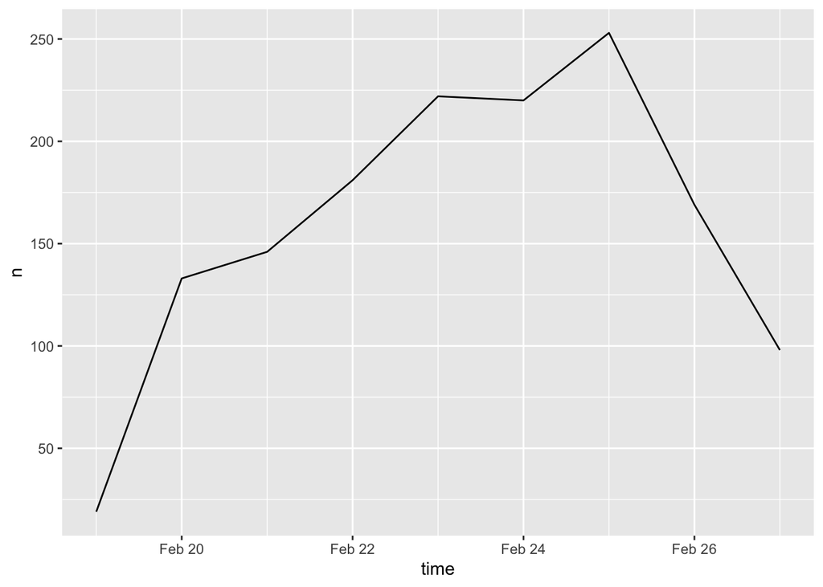

```r
ts_plot(tweets, by = "days")
```

Notice that this effectively creates a `ggplot` time series plot for us. I’ve included the `by =` argument which by default is set to “days”. It looks like tweets go back 9 days which the rate limit set by Twitter.

Try changing it to “hours” and see what happens.

##### ✅ Comprehension Check

1. Use `ts_plot` with the `group_by` function to compare the number of tweets over time by Next Gen and Common Core `standards`
2. Which set of standards is Twitter users talking about the most?

Hint: use the `?ts_plot` help function to check the examples to see how this can be done.

Your line graph should look something like this:

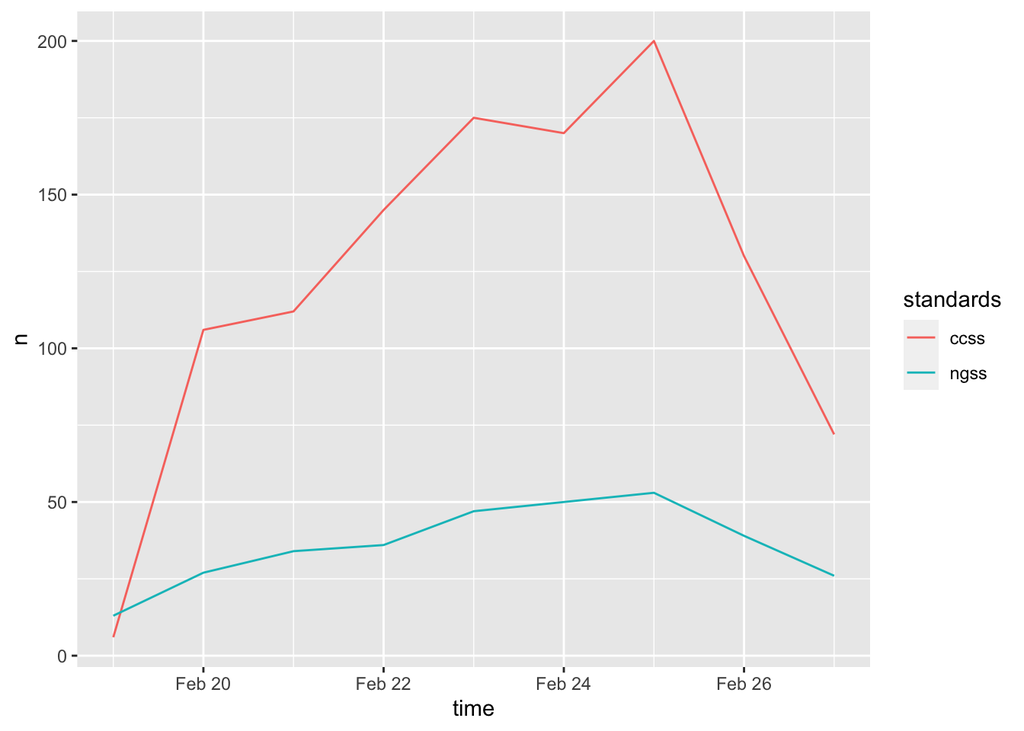

### 3b. Sentiment Summaries

Since our primary goals is to compare public sentiment around the NGSS and CCSS state standards, in this section we put together some basic numerical summaries using our different lexicons to see whether tweets are generally more positive or negative for each standard as well as differences between the two. To do this, we revisit the following `dplyr` functions:

- [`count()`](https://dplyr.tidyverse.org/reference/count.html?q=count) lets you quickly count the unique values of one or more variables
- [`group_by()`](https://dplyr.tidyverse.org/articles/grouping.html?q=group) takes a data frame and one or more variables to group by
- [`summarise()`](https://dplyr.tidyverse.org/reference/summarise.html) creates a numerical summary of data using arguments like [`mean()`](https://rdrr.io/r/base/mean.html) and [`median()`](https://rdrr.io/r/stats/median.html)
- [`mutate()`](https://dplyr.tidyverse.org/reference/mutate.html) adds new variables and preserves existing ones

And introduce one new function:

- `spread()`

#### Sentiment Counts

Let’s start with `bing`, our simplest sentiment lexicon, and use the `count` function to count how many times in our `sentiment_bing` data frame “positive” and “negative” occur in `sentiment` column and :

```r
summary_bing <- count(sentiment_bing, sentiment, sort = TRUE)
```

```r
summary_bing
```

```
## # A tibble: 2 x 2
##   sentiment     n
##   <chr>     <int>
## 1 negative    974
## 2 positive    663
```

Since our main goal is to compare positive and negative sentiment between CCSS and NGSS, let’s use the `group_by` function again to get `sentiment` summaries for NGSS and CCSS separately:

```r
summary_bing <- sentiment_bing %>%
  group_by(standards) %>%
  count(sentiment)

summary_bing
```

```
## # A tibble: 4 x 3
## # Groups:   standards [2]
##   standards sentiment     n
##   <chr>     <chr>     <int>
## 1 ccss      negative    914
## 2 ccss      positive    437
## 3 ngss      negative     60
## 4 ngss      positive    226
```

Looks like CCSS have far more negative words than positive, while NGSS skews much more positive. So far, pretty consistent with Rosenberg et al. findings!!!

#### Compute Sentiment Value

Our last step will be calculate a single sentiment “score” for our tweets that we can use for quick comparison and create a new variable indicating which lexicon we used.

First, let’s untidy our data a little by using the `spread` function from the `tidyr` package to transform our `sentiment` column into separate columns for `negative` and `positive` that contains the `n` counts for each:

```r
summary_bing <- sentiment_bing %>%
  group_by(standards) %>%
  count(sentiment, sort = TRUE) %>%
  spread(sentiment, n)

summary_bing
```

```
## # A tibble: 2 x 3
## # Groups:   standards [2]
##   standards negative positive
##   <chr>        <int>    <int>
## 1 ccss           914      437
## 2 ngss            60      226
```

Finally, we’ll use the `mutate` function to create two new variables: `sentiment` and `lexicon` so we have a single sentiment score and the lexicon from which it was derived:

```r
summary_bing <- sentiment_bing %>%
  group_by(standards) %>%
  count(sentiment, sort = TRUE) %>%
  spread(sentiment, n) %>%
  mutate(sentiment = positive - negative) %>%
  mutate(lexicon = "bing") %>%
  relocate(lexicon)

summary_bing
```

```
## # A tibble: 2 x 5
## # Groups:   standards [2]
##   lexicon standards negative positive sentiment
##   <chr>   <chr>        <int>    <int>     <int>
## 1 bing    ccss           914      437      -477
## 2 bing    ngss            60      226       166
```

There we go, now we can see that CCSS scores negative, while NGSS is overall positive.

Let’s calculate a quick score for using the `afinn` lexicon now. Remember that AFINN provides a value from -5 to 5 for each:

```r
head(sentiment_afinn)
```

```
## # A tibble: 6 x 5
##   standards screen_name  created_at          word         value
##   <chr>     <chr>        <dttm>              <chr>        <dbl>
## 1 ngss      loyr2662     2021-02-27 17:33:27 win              4
## 2 ngss      Furlow_teach 2021-02-27 17:03:23 love             3
## 3 ngss      Furlow_teach 2021-02-27 17:03:23 sweet            2
## 4 ngss      Furlow_teach 2021-02-27 17:03:23 significance     1
## 5 ngss      TdiShelton   2021-02-27 14:17:34 honored          2
## 6 ngss      TdiShelton   2021-02-27 14:17:34 opportunity      2
```

To calculate late a summary score, we will need to first group our data by `standards` again and then use the `summarise` function to create a new `sentiment` variable by adding all the positive and negative scores in the `value` column:

```r
summary_afinn <- sentiment_afinn %>%
  group_by(standards) %>%
  summarise(sentiment = sum(value)) %>%
  mutate(lexicon = "AFINN") %>%
  relocate(lexicon)

summary_afinn
```

```
## # A tibble: 2 x 3
##   lexicon standards sentiment
##   <chr>   <chr>         <dbl>
## 1 AFINN   ccss           -833
## 2 AFINN   ngss            502
```

Again, CCSS is overall negative while NGSS is overall positive!

##### ✅ Comprehension Check

For your final task for this walkthough, calculate a single sentiment score for NGSS and CCSS using the remaining `nrc` and `loughan` lexicons and answer the following questions. Are these findings above still consistent?

Hint: The `nrc` lexicon contains “positive” and “negative” values just like `bing` and `loughan`, but also includes values like “trust” and “sadness” as shown below. You will need to use the `filter()` function to select rows that only contain “positive” and “negative.”

```r
nrc
```

```
## # A tibble: 13,901 x 2
##    word        sentiment
##    <chr>       <chr>
##  1 abacus      trust
##  2 abandon     fear
##  3 abandon     negative
##  4 abandon     sadness
##  5 abandoned   anger
##  6 abandoned   fear
##  7 abandoned   negative
##  8 abandoned   sadness
##  9 abandonment anger
## 10 abandonment fear
## # … with 13,891 more rows
```

[output not shown]

[output not shown]

## 4. MODEL

As highlighted in [Chapter 3 of Data Science in Education Using R](https://datascienceineducation.com/c03.html), the **Model** step of the data science process entails “using statistical models, from simple to complex, to understand trends and patterns in the data.” The authors note that while descriptive statistics and data visualization during the **Explore** step can help us to identify patterns and relationships in our data, statistical models can be used to help us determine if relationships, patterns and trends are actually meaningful.

Recall from the PREPARE section that the Rosenberg et al. study was guide by the following questions:

1. What is the public sentiment expressed toward the NGSS?
2. How does sentiment for teachers differ from non-teachers?
3. How do tweets posted to #NGSSchat differ from those without the hashtag?
4. How does participation in #NGSSchat relate to the public sentiment individuals express?
5. How does public sentiment vary over time?

Similar to our sentiment summary using the AFINN lexicon, the Rosenberg et al. study used the -5 to 5 sentiment score from the SentiStrength lexicon to answer RQ #1. To address the remaining questions the authors used a mixed effects model (also known as multi-level or hierarchical linear models via the lme4 package in R.

## 5. COMMUNICATE

The final(ish) step in our workflow/process is sharing the results of analysis with wider audience. Krumm et al. (2018) outlined the following 3-step process for communicating with education stakeholders what you have learned through analysis:

1. **Select**. Communicating what one has learned involves selecting among those analyses that are most important and most useful to an intended audience, as well as selecting a form for displaying that information, such as a graph or table in static or interactive form, i.e. a “data product.”
2. **Polish**. After creating initial versions of data products, research teams often spend time refining or polishing them, by adding or editing titles, labels, and notations and by working with colors and shapes to highlight key points.
3. **Narrate**. Writing a narrative to accompany the data products involves, at a minimum, pairing a data product with its related research question, describing how best to interpret the data product, and explaining the ways in which the data product helps answer the research question.

### 5a. Select

Remember that the questions of interest that we want to focus on our for our selection, polishing, and narration include:

1. What is the public sentiment expressed toward the NGSS?
2. How does sentiment for NGSS compare to sentiment for CCSS?

### 5b. Polish

#### NGSS Sentiment

I want to try and replicate as closely as possible the approach Rosenberg et al. used in their analysis. To do that, I’ll I can recycle some R code I used in section 2b. Tidy Text.

To polish my analyses and prepare, first I need to rebuild the `tweets` dataset from my `ngss_tweets` and `ccss_tweets` and select both the `status_id` that is unique to each tweet, and the `text` column which contains the actual post:

```r
ngss_text <-
  ngss_tweets %>%
  filter(lang == "en") %>%
  select(status_id, text) %>%
  mutate(standards = "ngss") %>%
  relocate(standards)

ccss_text <-
  ccss_tweets %>%
  filter(lang == "en") %>%
  select(status_id, text) %>%
  mutate(standards = "ccss") %>%
  relocate(standards)

tweets <- bind_rows(ngss_text, ccss_text)

tweets
```

```
## # A tibble: 1,441 x 3
##    standards status_id        text
##    <chr>     <chr>            <chr>
##  1 ngss      136571669033664… "Switching gears for a bit for the \"Crosscutting…
##  2 ngss      136321751376141… "Was just introduced to the Engineering Habits of…
##  3 ngss      136570912276365… "@IBchemmilam @chemmastercorey I’m familiar w/ it…
##  4 ngss      136567329436042… "@IBchemmilam @chemmastercorey How well does this…
##  5 ngss      136566739318860… "I am so honored and appreciative to have an oppo…
##  6 ngss      136569047726628… "Thank you @brian_womack I loved connecting with …
##  7 ngss      136570614049613… "Please share #NGSSchat PLN! https://t.co/Qc2c3eW…
##  8 ngss      136366932814767… "So excited about this weekend’s learning... plea…
##  9 ngss      136544278654421… "The Educators Evaluating the Quality of Instruct…
## 10 ngss      136435814916417… "Foster existing teacher social networks that exh…
## # … with 1,431 more rows
```

The `status_id` is important because like Rosenberg et al., I want to calculate an overall sentiment score for each tweet, rather than for each word.

Before I get that far however, I’ll need to tidy my `tweets` again and attach my `sentiment` scores.

Note that the closest lexicon we have available in our `tidytext` package to the SentiStrength lexicon used by Rosenberg is the AFINN lexicon which also uses a -5 to 5 point scale.

So let’s use `unnest_tokens` to tidy our tweets, remove stop words, and add `afinn` scores to each word similar to what we did in section 2c. Add Sentiment Values:

```r
sentiment_afinn <- tweets %>%
  unnest_tokens(output = word,
                input = text,
                token = "tweets")  %>%
  anti_join(stop_words, by = "word") %>%
  filter(!word == "amp") %>%
  inner_join(afinn, by = "word")

sentiment_afinn
```

```
## # A tibble: 1,520 x 4
##    standards status_id           word         value
##    <chr>     <chr>               <chr>        <dbl>
##  1 ngss      1365716690336645124 win              4
##  2 ngss      1365709122763653133 love             3
##  3 ngss      1365709122763653133 sweet            2
##  4 ngss      1365709122763653133 significance     1
##  5 ngss      1365667393188601857 honored          2
##  6 ngss      1365667393188601857 opportunity      2
##  7 ngss      1365667393188601857 wonderful        4
##  8 ngss      1365667393188601857 powerful         2
##  9 ngss      1365690477266284545 loved            3
## 10 ngss      1365706140496130050 share            1
## # … with 1,510 more rows
```

Next, I want to calculate a single score for each tweet. To do that, I’ll use the by now familiar `group_by` and `summarize`

```r
afinn_score <- sentiment_afinn %>%
  group_by(standards, status_id) %>%
  summarise(value = sum(value))

afinn_score
```

```
## # A tibble: 842 x 3
## # Groups:   standards [2]
##    standards status_id           value
##    <chr>     <chr>               <dbl>
##  1 ccss      1362894990813188096    -2
##  2 ccss      1362899370199445508     4
##  3 ccss      1362906588021989376    -2
##  4 ccss      1362910494487535618    -9
##  5 ccss      1362910913855160320    -3
##  6 ccss      1362928225379250179     2
##  7 ccss      1362933982074073090    -1
##  8 ccss      1362947497258151945    -3
##  9 ccss      1362949805694013446     3
## 10 ccss      1362970614282264583     3
## # … with 832 more rows
```

And like Rosenberg et al., I’ll add a flag for whether the tweet is “positive” or “negative” using the `mutate` function to create a new `sentiment` column to indicate whether that tweets was positive or negative.

To do this, we introduced the new `if_else` function from the `dplyr` package. This `if_else` function adds “negative” to the `sentiment` column if the score in the `value` column of the corresponding row is less than 0. If not, it will add a “positive” to the row.

```r
afinn_sentiment <- afinn_score %>%
  filter(value != 0) %>%
  mutate(sentiment = if_else(value < 0, "negative", "positive"))

afinn_sentiment
```

```
## # A tibble: 801 x 4
## # Groups:   standards [2]
##    standards status_id           value sentiment
##    <chr>     <chr>               <dbl> <chr>
##  1 ccss      1362894990813188096    -2 negative
##  2 ccss      1362899370199445508     4 positive
##  3 ccss      1362906588021989376    -2 negative
##  4 ccss      1362910494487535618    -9 negative
##  5 ccss      1362910913855160320    -3 negative
##  6 ccss      1362928225379250179     2 positive
##  7 ccss      1362933982074073090    -1 negative
##  8 ccss      1362947497258151945    -3 negative
##  9 ccss      1362949805694013446     3 positive
## 10 ccss      1362970614282264583     3 positive
## # … with 791 more rows
```

Note that since a tweet sentiment score equal to 0 is neutral, I used the `filter` function to remove it from the dataset.

Finally, we’re ready to compute our ratio. We’ll use the `group_by` function and `count` the number of tweets for each of the `standards` that are positive or negative in the `sentiment` column. Then we’ll use the `spread` function to separate them out into separate columns so we can perform a quick calculation to compute the `ratio`.

```r
afinn_ratio <- afinn_sentiment %>%
  group_by(standards) %>%
  count(sentiment) %>%
  spread(sentiment, n) %>%
  mutate(ratio = negative/positive)

afinn_ratio
```

```
## # A tibble: 2 x 4
## # Groups:   standards [2]
##   standards negative positive ratio
##   <chr>        <int>    <int> <dbl>
## 1 ccss           417      202 2.06
## 2 ngss            18      164 0.110
```

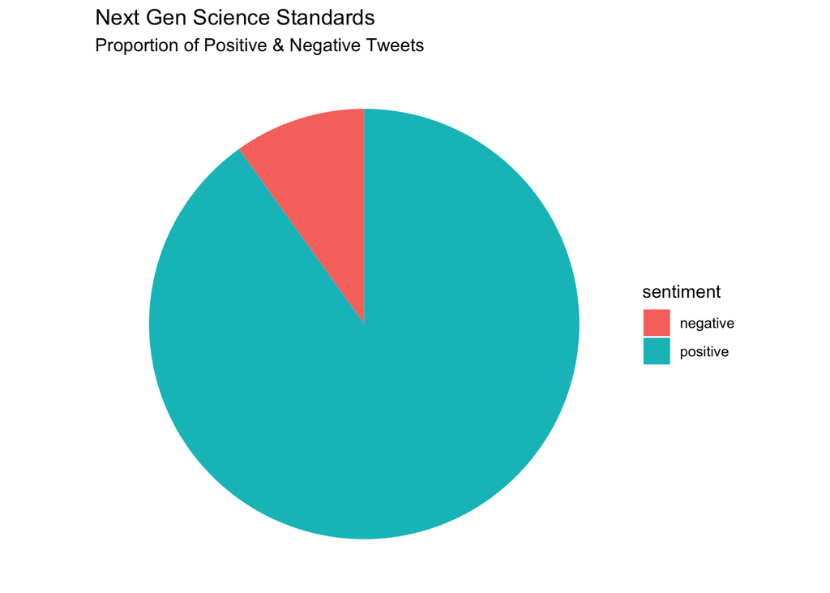

```r
afinn_counts <- afinn_sentiment %>%
  group_by(standards) %>%
  count(sentiment) %>%
  filter(standards == "ngss")

afinn_counts %>%
ggplot(aes(x="", y=n, fill=sentiment)) +
  geom_bar(width = .6, stat = "identity") +
  labs(title = "Next Gen Science Standards",
       subtitle = "Proportion of Positive & Negative Tweets") +
  coord_polar(theta = "y") +
  theme_void()
```

#### NGSS vs CCSS

Finally, to address Question 2, I want to compare the percentage of positive and negative words contained in the corpus of tweets for the NGSS and CCSS standards using the four different lexicons to see how sentiment compares based on lexicon used.

I’ll begin by polishing my previous summaries and creating identical summaries for each lexicon that contains the following columns: `method`, `standards`, `sentiment`, and `n`, or word counts:

```r
summary_afinn2 <- sentiment_afinn %>%
  group_by(standards) %>%
  filter(value != 0) %>%
  mutate(sentiment = if_else(value < 0, "negative", "positive")) %>%
  count(sentiment, sort = TRUE) %>%
  mutate(method = "AFINN")

summary_bing2 <- sentiment_bing %>%
  group_by(standards) %>%
  count(sentiment, sort = TRUE) %>%
  mutate(method = "bing")

summary_nrc2 <- sentiment_nrc %>%
  filter(sentiment %in% c("positive", "negative")) %>%
  group_by(standards) %>%
  count(sentiment, sort = TRUE) %>%
  mutate(method = "nrc")

summary_loughran2 <- sentiment_loughran %>%
  filter(sentiment %in% c("positive", "negative")) %>%
  group_by(standards) %>%
  count(sentiment, sort = TRUE) %>%
  mutate(method = "loughran")
```

Next, I’ll combine those four data frames together using the `bind_rows` function again:

```r
summary_sentiment <- bind_rows(summary_afinn2,
                               summary_bing2,
                               summary_nrc2,
                               summary_loughran2) %>%
  arrange(method, standards) %>%
  relocate(method)

summary_sentiment
```

```
## # A tibble: 16 x 4
## # Groups:   standards [2]
##    method   standards sentiment     n
##    <chr>    <chr>     <chr>     <int>
##  1 AFINN    ccss      negative    740
##  2 AFINN    ccss      positive    468
##  3 AFINN    ngss      positive    273
##  4 AFINN    ngss      negative     39
##  5 bing     ccss      negative    914
##  6 bing     ccss      positive    437
##  7 bing     ngss      positive    226
##  8 bing     ngss      negative     60
##  9 loughran ccss      negative    440
## 10 loughran ccss      positive    112
## 11 loughran ngss      negative     68
## 12 loughran ngss      positive     54
## 13 nrc      ccss      positive   2212
## 14 nrc      ccss      negative    774
## 15 nrc      ngss      positive    544
## 16 nrc      ngss      negative     74
```

Then I’ll create a new data frame that has the total word counts for each set of standards and each method and join that to my `summary_sentiment` data frame:

```r
total_counts <- summary_sentiment %>%
  group_by(method, standards) %>%
  summarise(total = sum(n))
sentiment_counts <- left_join(summary_sentiment, total_counts)
sentiment_counts
```

```
## # A tibble: 16 x 5
## # Groups:   standards [2]
##    method   standards sentiment     n total
##    <chr>    <chr>     <chr>     <int> <int>
##  1 AFINN    ccss      negative    740  1208
##  2 AFINN    ccss      positive    468  1208
##  3 AFINN    ngss      positive    273   312
##  4 AFINN    ngss      negative     39   312
##  5 bing     ccss      negative    914  1351
##  6 bing     ccss      positive    437  1351
##  7 bing     ngss      positive    226   286
##  8 bing     ngss      negative     60   286
##  9 loughran ccss      negative    440   552
## 10 loughran ccss      positive    112   552
## 11 loughran ngss      negative     68   122
## 12 loughran ngss      positive     54   122
## 13 nrc      ccss      positive   2212  2986
## 14 nrc      ccss      negative    774  2986
## 15 nrc      ngss      positive    544   618
## 16 nrc      ngss      negative     74   618
```

Finally, I’ll add a new row that calculates the percentage of positive and negative words for each set of state standards:

```r
sentiment_percents <- sentiment_counts %>%
  mutate(percent = n/total * 100)

sentiment_percents
```

```
## # A tibble: 16 x 6
## # Groups:   standards [2]
##    method   standards sentiment     n total percent
##    <chr>    <chr>     <chr>     <int> <int>   <dbl>
##  1 AFINN    ccss      negative    740  1208    61.3
##  2 AFINN    ccss      positive    468  1208    38.7
##  3 AFINN    ngss      positive    273   312    87.5
##  4 AFINN    ngss      negative     39   312    12.5
##  5 bing     ccss      negative    914  1351    67.7
##  6 bing     ccss      positive    437  1351    32.3
##  7 bing     ngss      positive    226   286    79.0
##  8 bing     ngss      negative     60   286    21.0
##  9 loughran ccss      negative    440   552    79.7
## 10 loughran ccss      positive    112   552    20.3
## 11 loughran ngss      negative     68   122    55.7
## 12 loughran ngss      positive     54   122    44.3
## 13 nrc      ccss      positive   2212  2986    74.1
## 14 nrc      ccss      negative    774  2986    25.9
## 15 nrc      ngss      positive    544   618    88.0
## 16 nrc      ngss      negative     74   618    12.0
```

Now that I have my sentiment percent summaries for each lexicon, I’m going great my 100% stacked bar charts for each lexicon:

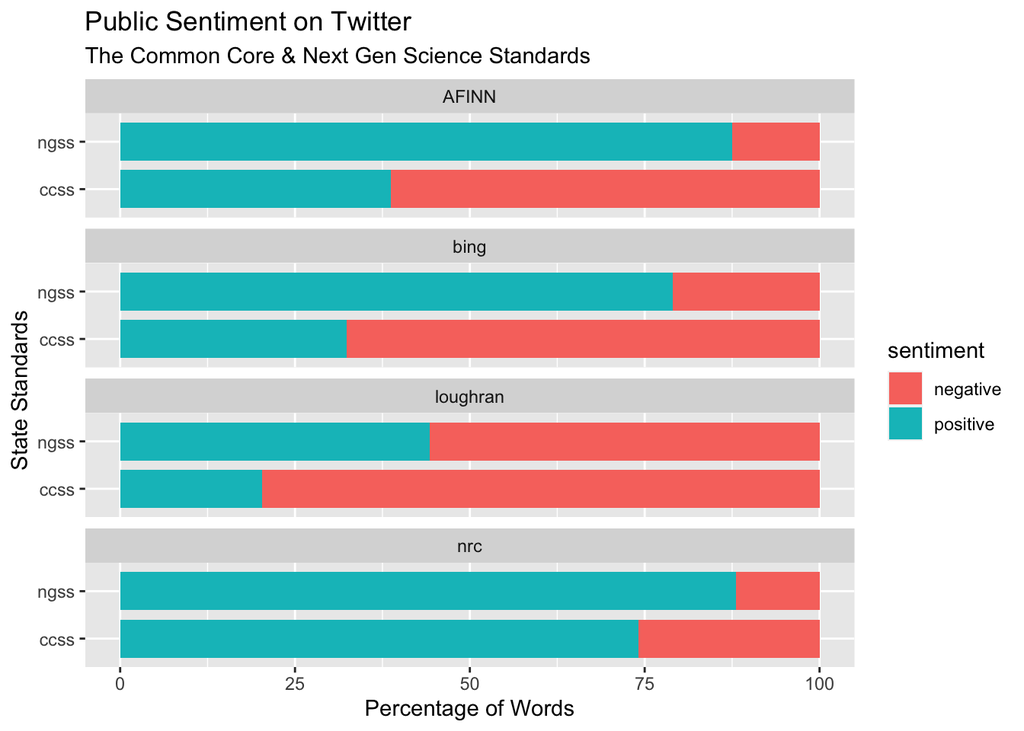

```r
sentiment_percents %>%
  ggplot(aes(x = standards, y = percent, fill=sentiment)) +
  geom_bar(width = .8, stat = "identity") +
  facet_wrap(~method, ncol = 1) +
  coord_flip() +
  labs(title = "Public Sentiment on Twitter",
       subtitle = "The Common Core & Next Gen Science Standards",
       x = "State Standards",
       y = "Percentage of Words")
```

And finished! The chart above clearly illustrates that regardless of sentiment lexicon used, the NGSS contains more positive words than the CCSS lexicon.

### 5c. Narrate

With our “data products” cleanup complete, we can start pulling together a quick presentation to share with the class. We’ve already seen what a more formal journal article looks like in the PREPARE section of this walkthrough. For your Independent Analysis assignment for Unit 2, you’ll be creating either a simple report or slide deck to share out some key findings from our analysis.

Regardless of whether you plan to talk us through your analysis and findings with a presentation or walk us through with a brief written report, your assignment should address the following questions:

1. **Purpose**. What question or questions are guiding your analysis? What did you hope to learn by answering these questions and why should your audience care about your findings?
2. **Methods**. What data did you selected for analysis? What steps did you take took to prepare your data for analysis and what techniques you used to analyze your data? These should be fairly explicit with your embedded code.
3. **Findings**. What did you ultimately find? How do your “data products” help to illustrate these findings? What conclusions can you draw from your analysis?
4. **Discussion**. What were some of the strengths and weaknesses of your analysis? How might your audience use this information? How might you revisit or improve upon this analysis in the future?

#### Examples and Templates

You can view my example presentation here: COMING SOON!

And use my R Markdown presentation file as a template: COMING SOON!